# Lab-3

Author

Dheeraj Oruganty

# Problem 1:

Plot probability density histograms for these discrete distributions (hint: use the d…() function).

1. Binomial Distribution

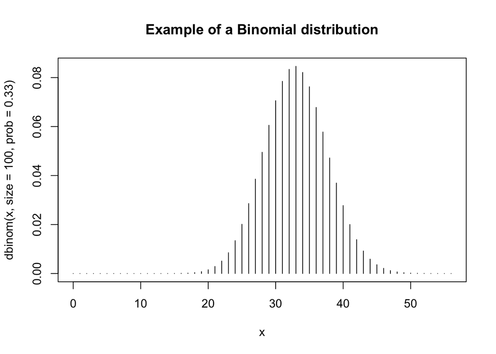

```r
x <- 0:56
p = 0.33
plot(x,dbinom(x,size=100,prob=0.33),type="h", main = "Example of a Binomial distribution")
```

2. Discrete uniform

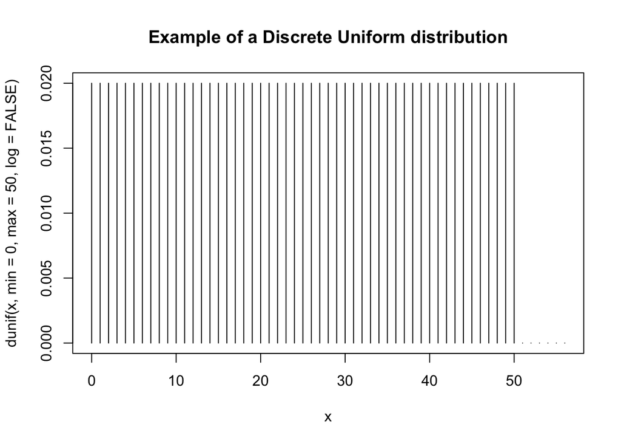

```r
library("extraDistr")

plot(x,dunif(x,min=0,max=50,log=FALSE),type="h", main = "Example of a Discrete Uniform distribution")
```

3. Bernoulli

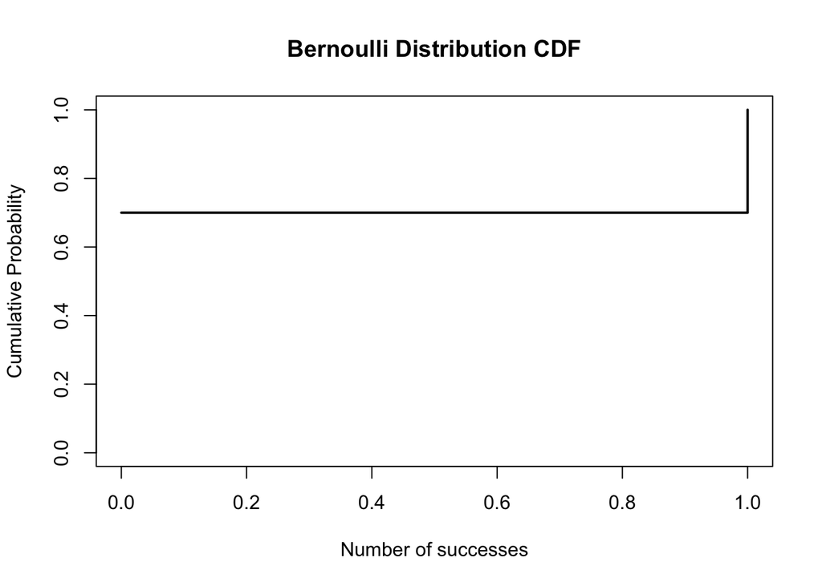

```r
p <- 0.3

x <- 0:1

cdf <- sapply(x, function(k)
pbinom(k, 1, p))

# Create the plot
plot(
x,
cdf,
type = "s",
lwd = 2,
ylim = c(0, 1),
xlab = "Number of successes",
ylab = "Cumulative Probability",
main = "Bernoulli Distribution CDF"
)
```

4. Poisson

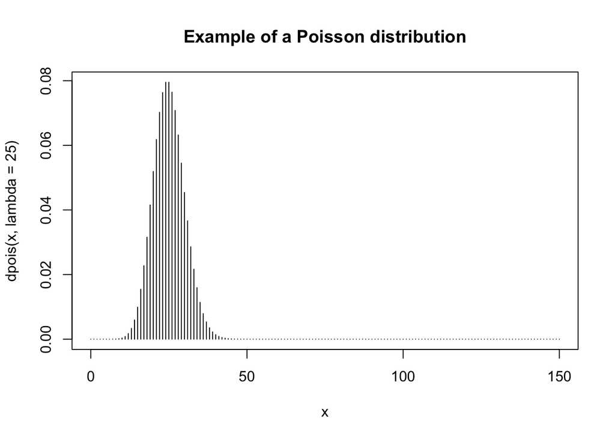

```r
x <- 0:150
plot(x,dpois(x,lambda=25),type="h", main = "Example of a Poisson distribution")
```

5. Geometric

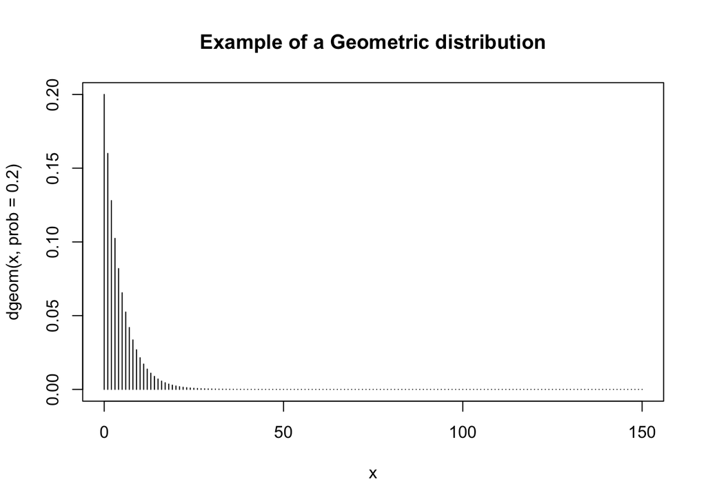

```r
plot(x,dgeom(x,prob=.2),type="h", main = "Example of a Geometric distribution")
```

6. Hyper-geometric

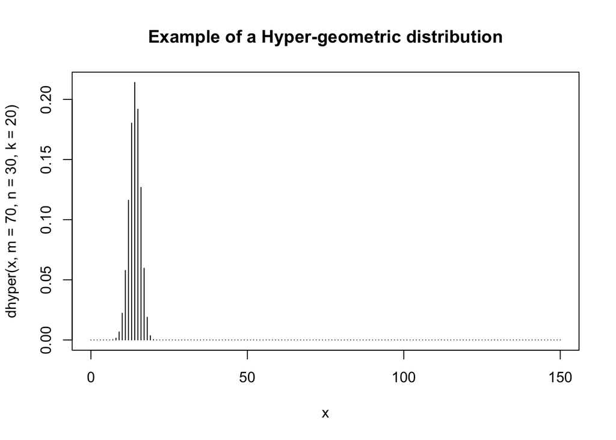

```r
plot(x,dhyper(x,m=70,n=30,k=20),type="h", main = "Example of a Hyper-geometric distribution")
```

7. Negative binomial

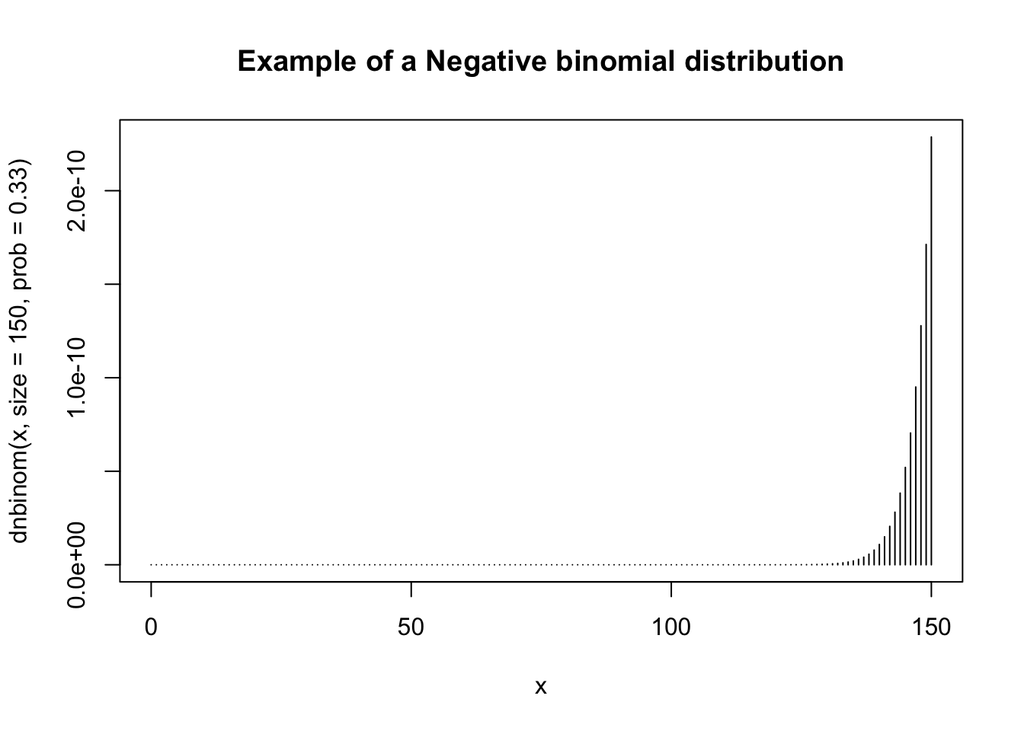

```r
plot(x,dnbinom(x,size=150,prob=.33),type="h", main = "Example of a Negative binomial distribution")
```

# Problem 2.

```r
(p4 <- dbinom(4,6,p=0.5) + dbinom(3,6,p=0.5) + dbinom(2,6,p=0.5) + dbinom(1,6,p=0.5) + dbinom(0,6,p=0.5))
```

```
[1] 0.890625
```

3. Compute the above probability(part-b) using *pbinom()*.

```r
pbinom(4,6,p=0.5)
```

```
[1] 0.890625
```

# Problem 3:

`use r to find the probability`

1. Assume an insurance company receives 3 motor vehicle insurance claims per week. What is the probability that they recieve 11 or fewer claims during a month?

$$P(X\le11)?$$

```r
a <- ppois(11,3*4)
a
```

```
[1] 0.4615973
```

2. While you are at the Georgetown library terrace, you notice that airplanes fly at an average rate of 1 every 4 hours. What is the probability that you will see at least one plane in the next hour?

```r
1 - ppois(0,0.25)
```

```
[1] 0.2211992
```

# Problem 4:

`Try this example with _..nbinom()_`

(This relates to Problem-1 in Lab-1 Assignment)

Mike had the first three successes in trials 6, 8, and 9. He had six failures until he reached three successes.

Do you think Mike has *success probability p = 0.5 or better?* Can a simulation give an answer?Let’s try.

1. If Mike’s success probability is p = 0.5 What is the probability that he will obtain these 3 successes?.

```r
successes <- 3
p <- 0.5
x <- 6
(prob <- dnbinom(x, size=successes, prob=p))
```

```
[1] 0.0546875
```

2. Run many simulations (say 10,000) with this success probability to find the same probability $P(X=6)?$ *Hint: Use rnbinom()*

```r
simulations <- rnbinom(1000000,size=successes,prob=p)
sum(simulations == 6)/length(simulations)
```

```
[1] 0.054736
```

3. If Mike’s success probability were 0.5 or better, he would not need a lot of attempts. Find the probability that three successes were reached after 9 tosses or later by somebody with success probability 0.5. $P(X\ge6)$
1. Calculate the probabiliy using both *dnbinom()* and *pnbinom()*.

```r
#Mike's success probability
pnbinom1 <- (1 - pnbinom(5,size=successes,prob=p))

dnbinom1 <- (1 - sum(sapply(0:5, function(x) dnbinom(x,size=successes,prob=p))))

pnbinom1
```

```
[1] 0.1445312
```

```r
dnbinom1
```

```
[1] 0.1445312
```

2. Calculate this probability using a Simulation(10,000)

```r
#probability using simulations
sim <- rnbinom(1000000,size=successes,prob=p)
sum(sim >= 6)/length(sim)
```

```
[1] 0.14441
```

3. Is this probability (part b) the same as you got from “myattempts”: Lab 1 Assignment Problem 1 part 3?

No, this is not the same probabability.